# Enunciados con su resolución

Julia

2023-10-22

# Problema 1

Aplicar todos los criterios de decisión bajo incertidumbre tanto para costos como para beneficios al problema cuya matriz de valores numéricos viene dada en la tabla siguiente:

|  | e1 | e2 | e3 |
| --- | --- | --- | --- |
| d1 | 1 | 3 | 9 |
| d2 | 4 | 3 | 7 |
| d3 | 5 | -2 | 6 |
| d4 | 1 | 2 | 0 |

## A continuación comenzaremos con su resolución utilizando los diferentes criterios:

### -Método wald

Para beneficios:

```r
wald_benef=criterio.Wald(tabla1,favorable = T)
wald_benef
```

```
## $criterio
## [1] "Wald"
##
## $metodo
## [1] "favorable"
##
## $tablaX
##    e1 e2 e3
## d1  1  3  9
## d2  4  3  7
## d3  5 -2  6
## d4  1  2  0
##
## $ValorAlternativas
## d1 d2 d3 d4
##  1  3 -2  0
##
## $ValorOptimo
## [1] 3
##
## $AlternativaOptima
## d2
##  2
```

La alternativa óptima es d2 con valor óptimo 3  
Para costos:

```r
wald_cost=criterio.Wald(tabla1,favorable = F)
wald_cost
```

```
## $criterio
## [1] "Wald"
##
## $metodo
## [1] "desfavorable"
##
## $tablaX
##    e1 e2 e3
## d1  1  3  9
## d2  4  3  7
## d3  5 -2  6
## d4  1  2  0
##
## $ValorAlternativas
## d1 d2 d3 d4
##  9  7  6  2
##
## $ValorOptimo
## [1] 2
##
## $AlternativaOptima
## d4
##  4
```

La alternativa óptima es d4 con valor óptimo 2

### -Método optimista

Para beneficios:

```r
opt_benef=criterio.Optimista(tabla1,T)
opt_benef
```

```
## $criterio
## [1] "Optimista"
##
## $metodo
## [1] "favorable"
##
## $tablaX
##    e1 e2 e3
## d1  1  3  9
## d2  4  3  7
## d3  5 -2  6
## d4  1  2  0
##
## $ValorAlternativas
## d1 d2 d3 d4
##  9  7  6  2
##
## $ValorOptimo
## [1] 9
##
## $AlternativaOptima
## d1
##  1
```

La alternativa óptima es d1 con valor óptimo 9  
Para costos:

```r
opt_cost=criterio.Optimista(tabla1,F)
opt_cost
```

```
## $criterio
## [1] "Optimista"
##
## $metodo
## [1] "desfavorable"
##
## $tablaX
##    e1 e2 e3
## d1  1  3  9
## d2  4  3  7
## d3  5 -2  6
## d4  1  2  0
##
## $ValorAlternativas
## d1 d2 d3 d4
##  1  3 -2  0
##
## $ValorOptimo
## [1] -2
##
## $AlternativaOptima
## d3
##  3
```

La alternativa óptima es d3 con valor óptimo -2

### -Método de hurwicz

Para beneficios:

```r
hurw_benef=criterio.Hurwicz(tabla1,alfa=0.5,favorable=T)
hurw_benef
```

```
## $criterio
## [1] "Hurwicz"
##
## $alfa
## [1] 0.5
##
## $metodo
## [1] "favorable"
##
## $tablaX
##    e1 e2 e3
## d1  1  3  9
## d2  4  3  7
## d3  5 -2  6
## d4  1  2  0
##
## $ValorAlternativas
## d1 d2 d3 d4
##  5  5  2  1
##
## $ValorOptimo
## [1] 5
##
## $AlternativaOptima
## d1 d2
##  1  2
```

Las alternativa óptimas son d1 y d2 con valor óptimo 5  
Para costos:

```r
hurw_cost=criterio.Hurwicz(tabla1,alfa=0.5,favorable=F)
hurw_cost
```

```
## $criterio
## [1] "Hurwicz"
##
## $alfa
## [1] 0.5
##
## $metodo
## [1] "desfavorable"
##
## $tablaX
##    e1 e2 e3
## d1  1  3  9
## d2  4  3  7
## d3  5 -2  6
## d4  1  2  0
##
## $ValorAlternativas
## d1 d2 d3 d4
##  5  5  2  1
##
## $ValorOptimo
## [1] 1
##
## $AlternativaOptima
## d4
##  4
```

La alternativa óptima es d4 con valor óptimo 1

Dibujemos a continuación el gráfico que muestra la mejor alternativa para cada valor de alfa en ambos casos:  
Para beneficios:

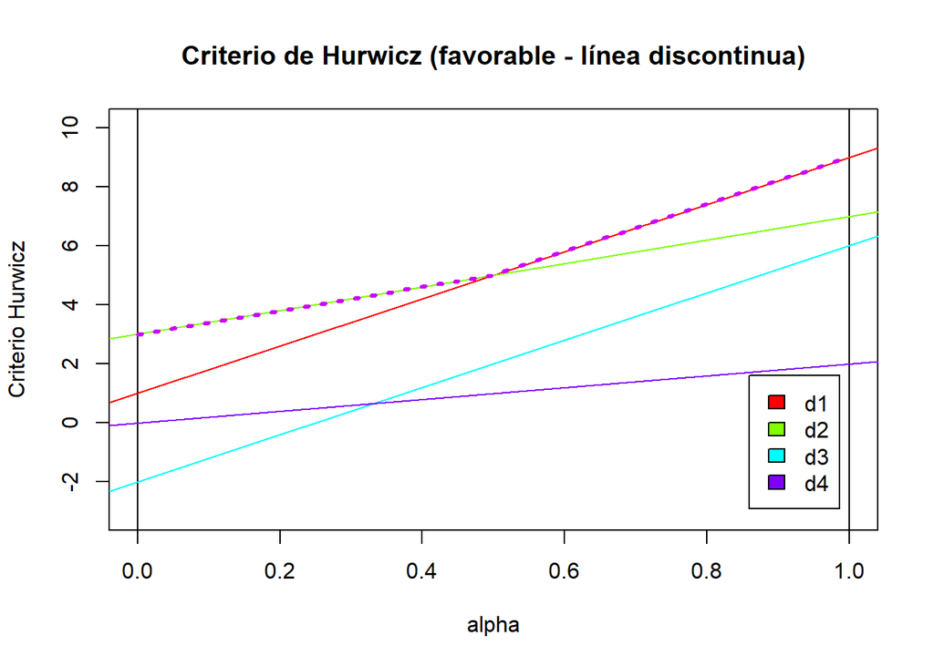

```r
dibuja.criterio.Hurwicz(tabla1,T)
```

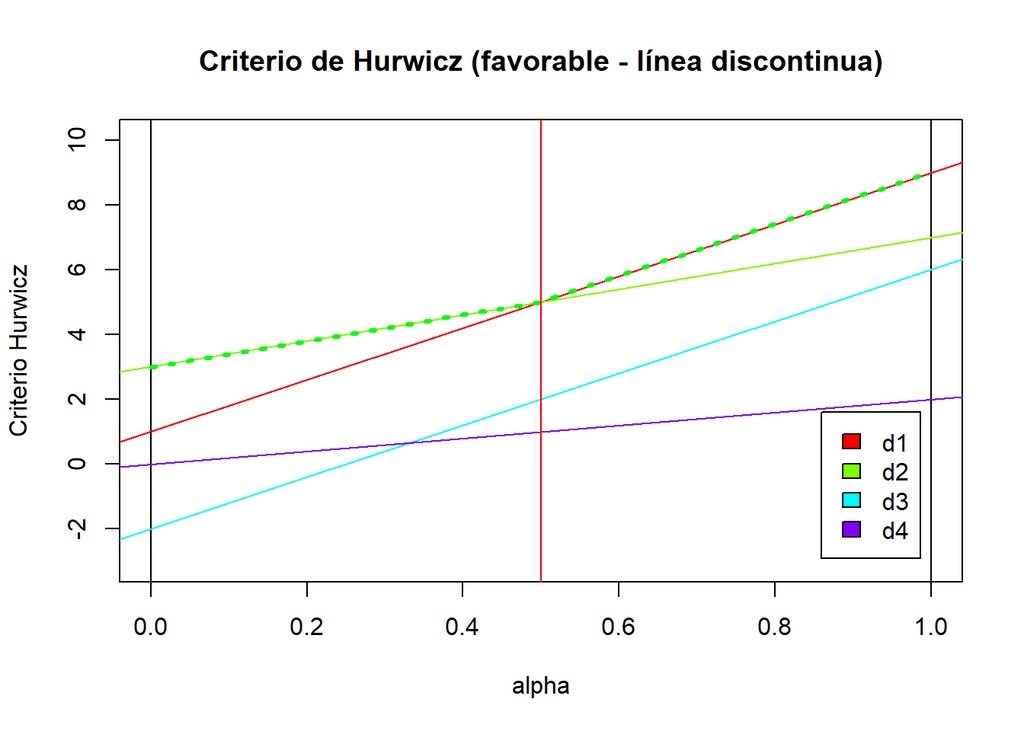

```
## $AltOptimas
## [1] 2 1
##
## $PuntosDeCorte
## [1] 0.5
##
## $IntervalosAlfa
##      Intervalo     Alternativa
## [1,] "( 0 , 0.5 )" "2"
## [2,] "( 0.5 , 1 )" "1"
```

```r
dibuja.criterio.Hurwicz_Intervalos(tabla1,T)
```

Para costos:

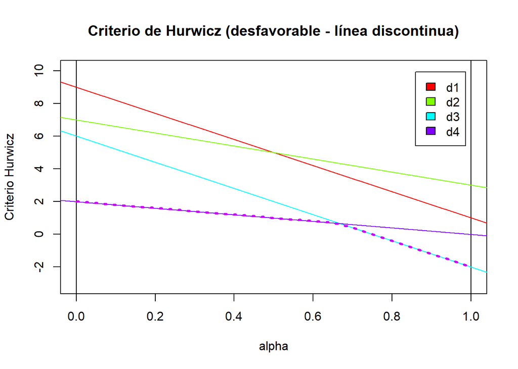

```r
dibuja.criterio.Hurwicz(tabla1,F)
```

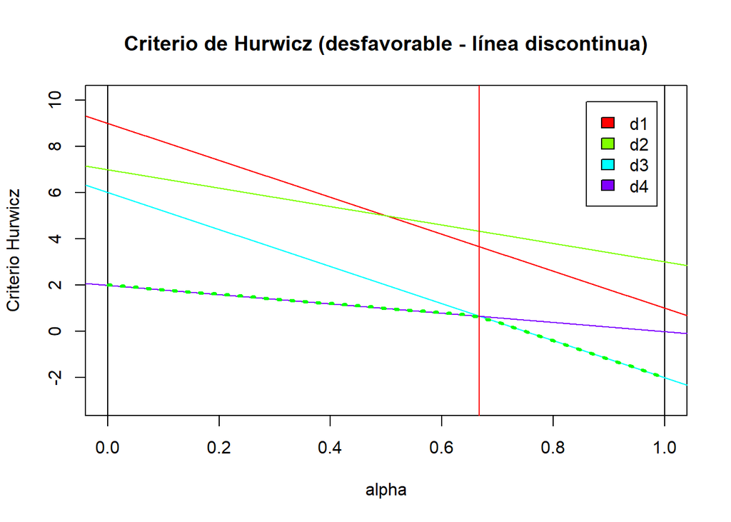

```
## $AltOptimas
## [1] 4 3
##
## $PuntosDeCorte
## [1] 0.667
##
## $IntervalosAlfa
##      Intervalo       Alternativa
## [1,] "( 0 , 0.667 )" "4"
## [2,] "( 0.667 , 1 )" "3"
```

```r
dibuja.criterio.Hurwicz_Intervalos(tabla1,F)
```

### -Método savage

Para beneficios:

```r
savg_benef=criterio.Savage(tabla1,T)
savg_benef
```

```
## $criterio
## [1] "Savage"
##
## $metodo
## [1] "favorable"
##
## $tablaX
##    e1 e2 e3
## d1  1  3  9
## d2  4  3  7
## d3  5 -2  6
## d4  1  2  0
##
## $Mejores
## e1 e2 e3
##  5  3  9
##
## $Pesos
##    e1 e2 e3
## d1  4  0  0
## d2  1  0  2
## d3  0  5  3
## d4  4  1  9
##
## $ValorAlternativas
## d1 d2 d3 d4
##  4  2  5  9
##
## $ValorOptimo
## [1] 2
##
## $AlternativaOptima
## d2
##  2
```

La alternativa óptima es d2 con valor óptimo 2  
Para costos:

```r
savg_cost=criterio.Savage(tabla1,F)
savg_cost
```

```
## $criterio
## [1] "Savage"
##
## $metodo
## [1] "desfavorable"
##
## $tablaX
##    e1 e2 e3
## d1  1  3  9
## d2  4  3  7
## d3  5 -2  6
## d4  1  2  0
##
## $Mejores
## e1 e2 e3
##  1 -2  0
##
## $Pesos
##    e1 e2 e3
## d1  0  5  9
## d2  3  5  7
## d3  4  0  6
## d4  0  4  0
##
## $ValorAlternativas
## d1 d2 d3 d4
##  9  7  6  4
##
## $ValorOptimo
## [1] 4
##
## $AlternativaOptima
## d4
##  4
```

La alternativa óptima es d4 con valor óptimo 4

### -Método de laplace

Para beneficios:

```r
laplc_benef=criterio.Laplace(tabla1,T)
laplc_benef
```

```
## $criterio
## [1] "Laplace"
##
## $metodo
## [1] "favorable"
##
## $tablaX
##    e1 e2 e3
## d1  1  3  9
## d2  4  3  7
## d3  5 -2  6
## d4  1  2  0
##
## $ValorAlternativas
##       d1       d2       d3       d4
## 4.333333 4.666667 3.000000 1.000000
##
## $ValorOptimo
## [1] 4.666667
##
## $AlternativaOptima
## d2
##  2
```

La alternativa óptima es d2 con valor óptimo 4,667  
Para costos:

```r
laplc_cost=criterio.Laplace(tabla1,F)
laplc_cost
```

```
## $criterio
## [1] "Laplace"
##
## $metodo
## [1] "desfavorable"
##
## $tablaX
##    e1 e2 e3
## d1  1  3  9
## d2  4  3  7
## d3  5 -2  6
## d4  1  2  0
##
## $ValorAlternativas
##       d1       d2       d3       d4
## 4.333333 4.666667 3.000000 1.000000
##
## $ValorOptimo
## [1] 1
##
## $AlternativaOptima
## d4
##  4
```

La alternativa óptima es d4 con valor óptimo 1

### -Método del punto ideal

Para beneficios:

```r
puntoId_benef=criterio.PuntoIdeal(tabla1,T)
puntoId_benef
```

```
## $criterio
## [1] "Punto Ideal"
##
## $metodo
## [1] "favorable"
##
## $tablaX
##    e1 e2 e3
## d1  1  3  9
## d2  4  3  7
## d3  5 -2  6
## d4  1  2  0
##
## $Mejores
## e1 e2 e3
##  5  3  9
##
## $ValorAlternativas
##       d1       d2       d3       d4
## 4.000000 2.236068 5.830952 9.899495
##
## $ValorOptimo
## [1] 2.236068
##
## $AlternativaOptima
## d2
##  2
```

La alternativa óptima es d2 con valor óptimo 2,236  
Para costos:

```r
puntoId_cost=criterio.PuntoIdeal(tabla1,F)
puntoId_cost
```

```
## $criterio
## [1] "Punto Ideal"
##
## $metodo
## [1] "desfavorable"
##
## $tablaX
##    e1 e2 e3
## d1  1  3  9
## d2  4  3  7
## d3  5 -2  6
## d4  1  2  0
##
## $Mejores
## e1 e2 e3
##  1 -2  0
##
## $ValorAlternativas
##        d1        d2        d3        d4
## 10.295630  9.110434  7.211103  4.000000
##
## $ValorOptimo
## [1] 4
##
## $AlternativaOptima
## d4
##  4
```

La alternativa óptima es d4 con valor óptimo 4

# Problema 2

Jimena esta planeando un viaje de 3 días a malta con su pareja pero no sabe que hotel reservar.Las tres opciones que le ha dado la agencia son:

Hotel St.George`s: Alojamiento+vuelo+desayuno 419€ / Todo incuido: 549€  
Alexandra hotel: Alojamiento+vuelo+desayuno 479€ / Todo incluido: 536€  
Qawara palace horel: Alojamiento+vuelo+desayuno 439€ / Todo incluido: 560€

Teniendo en cuenta que se gastarían una media de 22€ y 18€ en comer y cenar respectivamente ¿Cual deberia escoger?

## A continuación comenzaremos con su resolución utilizando todos los criterios a la vez:

Creamos la tabla con la que trabajaremos:

```r
p11=419+22*3+18*3
p12=549
p21=479+22*3+18*3
p22=536
p31=439+22*3+18*3
p32=560
tabla2=crea.tablaX(c(p11,p12,
                     p21,p22,
                     p31,p32),3,2)
kable(tabla2)
```

|  | e1 | e2 |
| --- | --- | --- |
| d1 | 539 | 549 |
| d2 | 599 | 536 |
| d3 | 559 | 560 |

Resolvemos el problema:

```r
sol=criterio.Todos(tabla2,F)
sol
```

```
##                  e1  e2 Wald Optimista Hurwicz Savage Laplace Punto Ideal
## d1              539 549  539       549     539     60   544.0          61
## d2              599 536  536       599     536     24   567.5          24
## d3              559 560  559       560     559     40   559.5          40
## iAlt.Opt (fav.)  --  --   d3        d2      d3     d2      d2          d2
```

Se puede ver que en 4 de ellos se elige el hotel número 2 y en 2 de ellos (Wald,Hurwicz) se elige el hotel número 3.